# Разведочный и причинно-следственный анализ

Забродин Вадим

26.10.2026

# Введение

Цель работы — показать на реальных исследованиях, как применяются два вида анализа:

1. **Разведочный анализ**
2. **Причинно-следственный анализ**

Репозиторий проекта на GitHub: https://github.com/scvrylullaby/r-dev

> «Работа не волк. Никто не волк. Только волк — волк.».

> — Джейсон Стетхам

# Разведочный анализ данных

## Суть метода

Разведочный анализ применяется для следующих задач:

- описать данные с помощью описательных статистик
- найти связи между переменными
- выявить структуру, группы и выбросы
- визуализировать данные и сформулировать гипотезы для дальнейшей проверки

## Пример исследования

**Статья:** Пиголкин Ю. И., Солодовников В. И., Золотенков Д. Д., Салем Б. Р., Полетаева М. П., Золотенкова Г. В. *Опыт использования Data Analysis исследовательских данных при решении задачи установления целевой возрастной группы* // Судебно-медицинская экспертиза. 2024. Т. 67, № 4. С. 37–41. DOI: 10.17116/sudmed20246704137.

### Данные

Исследованы КТ-снимки коленного сустава 303 человек (175 мужчин, 128 женщин) в возрасте 13–21 года. Для дистального эпифиза бедренной кости, проксимальных эпифизов большеберцовой и малоберцовой костей измерялась степень сращения (синостоза). Измерения делились на максимальную ширину метафиза, так получались относительные показатели FeR, TiR и FiR. Итоговый показатель:

$$FTF = FeR + TiR + FiR$$

### Применённые методы

1. Описательные статистики и коэффициент детерминации $R^2$ (Excel, SPSS).
2. Снижение размерности и визуализация методом UMAP.
3. Кластеризация методом KMeans; качество оценивалось коэффициентом
   $$s(i) = \frac{b(i) - a(i)}{\max\{a(i),\, b(i)\}},$$
   где $a(i)$ — среднее расстояние от объекта до объектов своего кластера, $b(i)$ — до объектов ближайшего чужого кластера.
4. Сравнение кластеров критериями Краскела — Уоллиса и Манна — Уитни.
5. Интерпретация модели с помощью значений SHAP; визуализация диаграммами boxplot и pairplot.

### Результаты

Связь показателей синостоза с возрастом (R²)

| Показатель | R2, вся выборка (n = 303) |
| --- | --- |
| FeR | 0.857 |
| TiR | 0.805 |
| FiR | 0.810 |
| FTF | 0.870 |

Лучшее разбиение дала кластеризация на 3 кластера (силуэт 0,67). Средний возраст в кластерах — около 14,5, 16,7 и 18,9 года, различия между кластерами значимы ($p < 0{,}00001$).

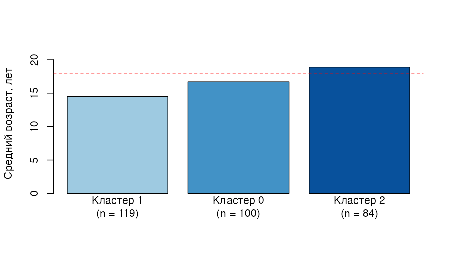

Средний возраст в кластерах; пунктир — порог 18 лет

### Почему это разведочный анализ

- У авторов не было готовой модели
- Основной инструмент — описание и визуализация
- Гипотеза по итогу о том, что показатель FTF можно использовать как дополнительный критерий отнесения человека к целевой возрастной группе

# Причинно-следственный анализ

## Суть метода

Причинно-следственный анализ отвечает на вопрос, **вызывает ли** изменение одной переменной изменение другой

## Пример исследования

**Статья:** Федин А. И., Захаров В. В., Танашян М. М. и др. *Результаты международного многоцентрового рандомизированного двойного слепого плацебо-контролируемого исследования оценки эффективности и безопасности последовательной терапии пациентов с хронической ишемией мозга (исследование МЕМО)* // Журнал неврологии и психиатрии им. С. С. Корсакова. 2021. Т. 121, № 11. С. 7–16.

### Дизайн

- 318 пациентов 40–90 лет с хронической ишемией мозга и умеренными когнитивными нарушениями, 15 центров в России и Узбекистане.
- Рандомизация 1:1: группа 1 получала Мексидол, группа 2 — плацебо по той же схеме
- Ни пациент, ни врач не знали, кто что получает
- Первичная конечная точка — изменение балла по шкале MoCA

### Применённые методы

1. t-критерий Стьюдента для независимых выборок:
   $$t = \frac{\bar{x}_1 - \bar{x}_2}{\sqrt{\dfrac{s_1^2}{n_1} +
   \dfrac{s_2^2}{n_2}}}$$
2. 95% доверительный интервал для разности средних:
   $$(\bar{x}_1 - \bar{x}_2) \pm t_{0{,}975}\, SE$$
3. Критерий Манна — Уитни для вторичных шкал, $\chi^2$ Пирсона и точный критерий Фишера для категориальных данных.
4. Относительный риск нежелательных явлений: $RR = \dfrac{p_1}{p_2}$.

### Результаты

Основные результаты исследования МЕМО

| Показатель | Мексидол (n = 159) | Плацебо (n = 159) | p |
| --- | --- | --- | --- |
| Прирост MoCA, баллы (M ± SD) | 4,22 ± 2,59 | 2,17 ± 2,20 | < 0,000001 |
| Пациенты с нежелательными явлениями | 15 (9,43%) | 21 (13,21%) | 0,288 |

Разница по MoCA между группами — 2,05 балла, 95% ДИ [1,51; 2,58].

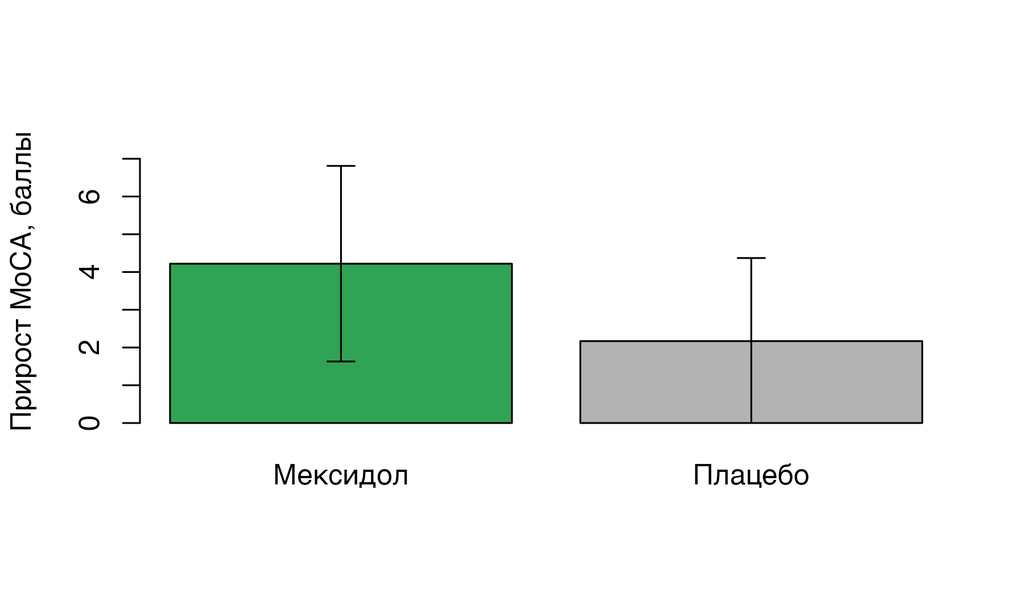

### Почему это причинно-следственный анализ

- Исследователи **сами задали воздействие** (препарат или плацебо)
- Курс около 74 дней без отдалённого наблюдения

# Сравнение видов анализа

| Критерий | Разведочный | Причинно-следственный |
| --- | --- | --- |
| Главный вопрос | Что есть в данных? | Что вызывает эффект? |
| Гипотеза | Формулируется в конце | Задаётся до начала |
| Типичные методы | Описательная статистика, UMAP, кластеризация | РКИ, t-критерий, доверительные интервалы |
| Пример | Возрастные группы по КТ колена | Исследование МЕМО |
| Результат | Новая гипотеза | Вывод о причинной связи |